# Multivariate Data Visualization in R

Shrihari Kakakoti

2025-02-25

# Introduction

This project explores multivariate data visualization techniques in R using a dataset of personal contacts. The aim is to highlight how data with multiple variables can be effectively represented and analyzed visually.

# Background

Multivariate data visualization helps in uncovering patterns, correlations, and insights in high-dimensional datasets. In this case study, we visualize attributes such as maximum temperature, weight, height, gender, year of acquaintance, and perceived company quality.

## Ask

How can we visually represent multivariate data to better understand relationships between variables and identify patterns?

## Prepare

We use a sample dataset containing the following variables: - Contact - Maxtemp - Weight - Height - Year - Gender - Company

### Data Preparation

```r
library(ggplot2)
library(readxl)
library(plot3D)
library(GGally)
library(aplpack)
```

```r
mydata <- read_excel("multivariate.xlsx")
head(mydata)
```

```
## # A tibble: 6 × 7
##   Contact  Maxtemp Weight Height  Year Gender Company
##   <chr>      <dbl>  <dbl>  <dbl> <dbl> <chr>  <chr>
## 1 Adrew         25     77    175    10 M      Good
## 2 Bernhand      31    110    195    12 M      Good
## 3 Carolina      15     70    172     2 F      Bad
## 4 Dennis        20     85    180    16 M      Good
## 5 Eve           10     65    168     0 F      Bad
## 6 Fred          12     75    173     6 M      Good
```

## Process

### Analyse

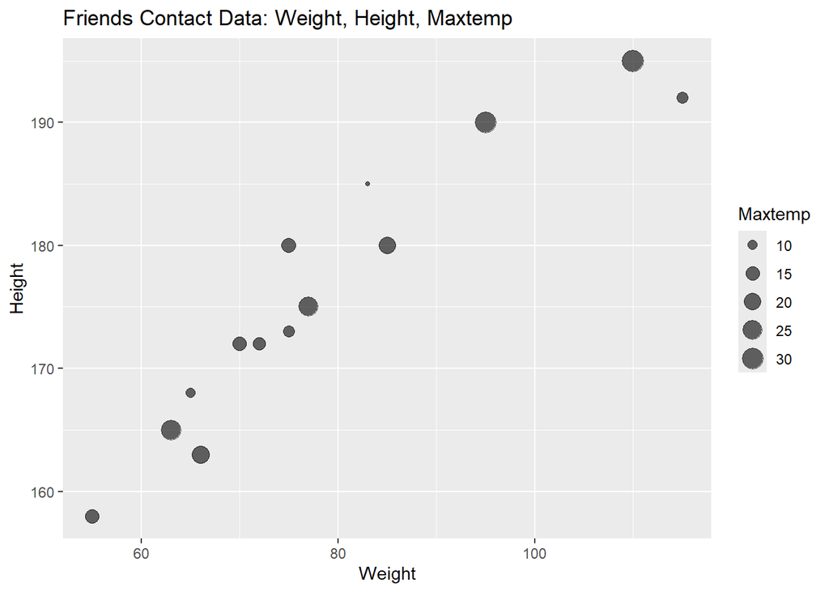

2D Plot: Weight vs Height sized by Max Temperature

```r
ggplot(mydata, aes(Weight, Height, size = Maxtemp)) +
  geom_point(alpha = 0.6) +
  labs(title = "Friends Contact Data: Weight, Height, Maxtemp")
```

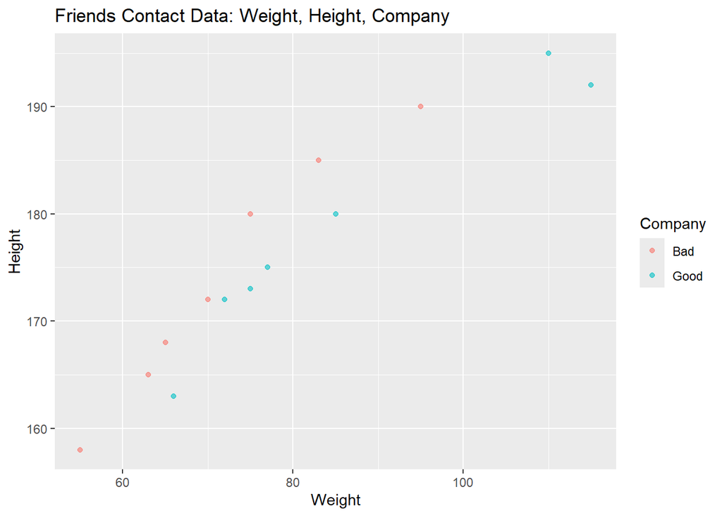

2D Plot: Weight vs Height colored by Company

```r
ggplot(mydata, aes(Weight, Height, colour = Company)) +
  geom_point(alpha = 0.6) +
  labs(title = "Friends Contact Data: Weight, Height, Company")
```

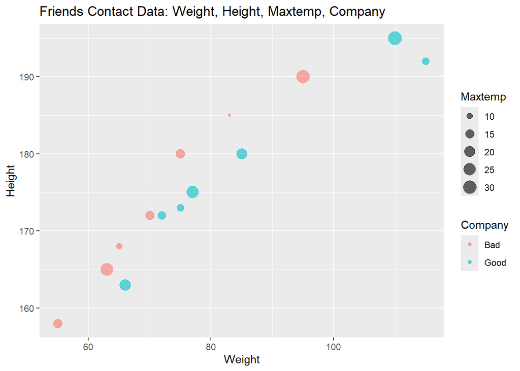

2D Plot: Weight vs Height colored by Company and sized by Max Temperature

```r
ggplot(mydata, aes(Weight, Height, colour = Company, size = Maxtemp)) +
  geom_point(alpha = 0.6) +
  labs(title = "Friends Contact Data: Weight, Height, Maxtemp, Company")
```

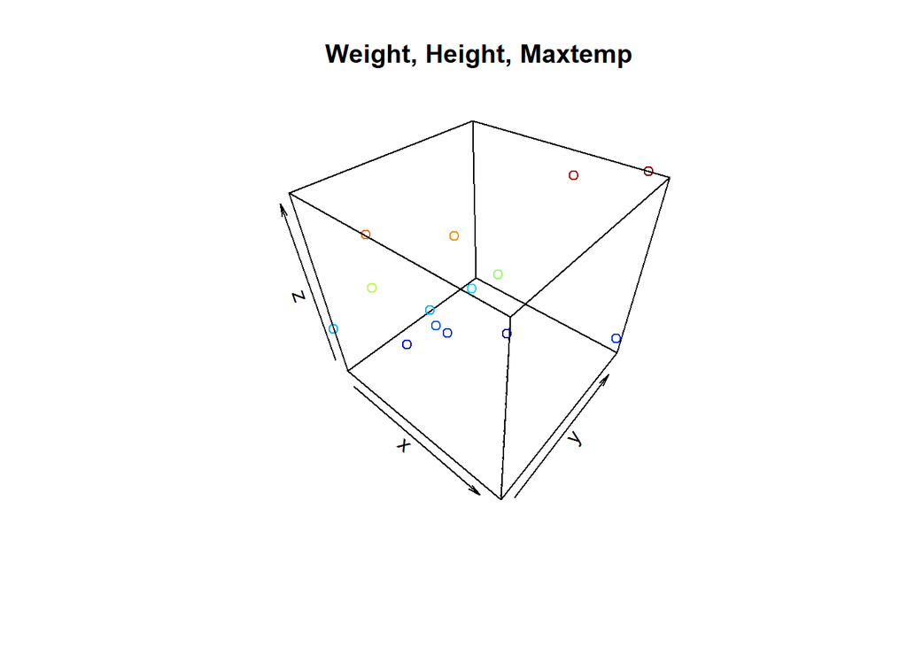

3D Plot: Weight vs Height vs Max Temperature

```r
scatter3D(x = mydata$Weight, y = mydata$Height, z = mydata$Maxtemp,
          bty = "f", colkey = FALSE, main = "Weight, Height, Maxtemp")
```

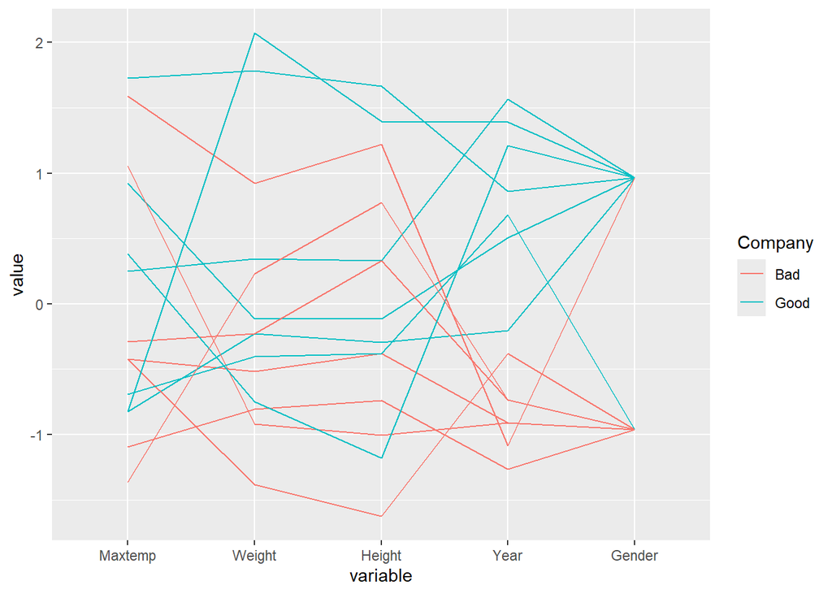

Parallel Coordinates Plot by Company

```r
ggparcoord(data = mydata, columns = 2:6, groupColumn = "Company")
```

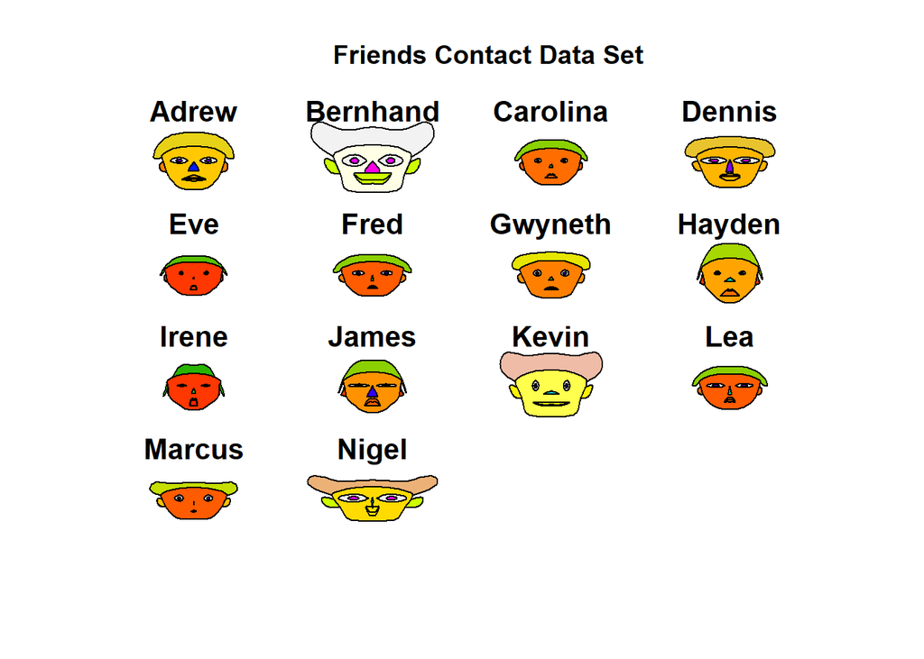

Chernoff Faces

```
## effect of variables:
##  modified item       Var
##  "height of face   " "Maxtemp"
##  "width of face    " "Weight"
##  "structure of face" "Height"
##  "height of mouth  " "Year"
##  "width of mouth   " "Maxtemp"
##  "smiling          " "Weight"
##  "height of eyes   " "Height"
##  "width of eyes    " "Year"
##  "height of hair   " "Maxtemp"
##  "width of hair   "  "Weight"
##  "style of hair   "  "Height"
##  "height of nose  "  "Year"
##  "width of nose   "  "Maxtemp"
##  "width of ear    "  "Weight"
##  "height of ear   "  "Height"
```

```r
faces(mydata[,2:5], face.type=1, scale=TRUE, main="Friends Contact Data Set",
      labels=mydata$Contact, print.info=TRUE)
```

## Share

All visualizations above help communicate patterns and relationships within the data. Each image is generated as a `.png` when knitting this document.

## Act

### Conclusion

Multivariate visualization provides a powerful way to explore and understand complex datasets. Using R libraries like `ggplot2`, `plot3D`, `GGally`, and `aplpack`, we can create engaging and insightful representations.

### Recommendations

- Use parallel coordinates for comparing multiple variables across different categories.
- Use Chernoff faces sparingly and only when interpretability is understood by the audience.
- Complement these visualizations with statistical summaries for deeper analysis.